# Applied Computational Methods for Social Sciences

## geom_point

### alpha(discrete)

Imagine we have data about 9 countries that record their level of democracy from -10 to +10 (x-axis) and their GDP per capita in $1,000s (y-axis).

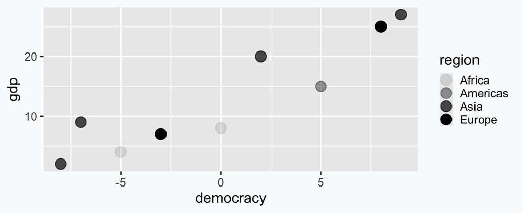

```r
# 8) alpha (discrete): subtle group differences; use sparingly in legends
ggplot(eg1, aes(x = democracy, y = gdp, alpha = region)) +
  geom_point()
```

## geom_point

### alpha(continuous)

Imagine we have data about 9 countries that record their level of democracy from -10 to +10 (x-axis) and their GDP per capita in $1,000s (y-axis).

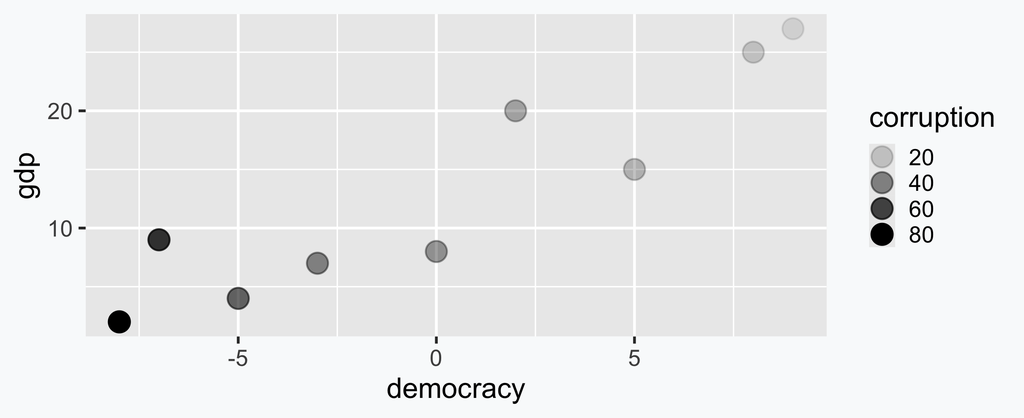

```r
# 9) alpha (continuous): opacity encodes intensity (higher → more opaque)
ggplot(eg1, aes(x = democracy, y = gdp, alpha = corruption)) +
  geom_point()
```

## geom_point

### multiple aesthetics (readable)

Imagine we have data about 9 countries that record their level of democracy from -10 to +10 (x-axis) and their GDP per capita in $1,000s (y-axis).

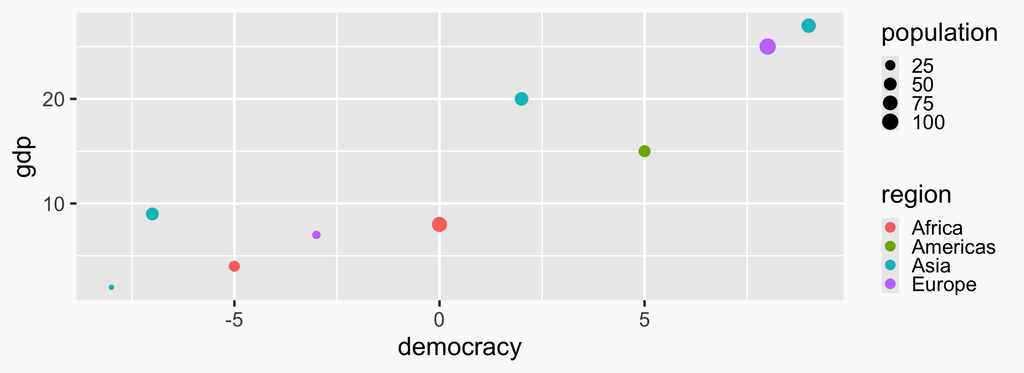

```r
# 10) Combine judiciously: color = region (discrete), size = population (continuous)
ggplot(eg1, aes(x = democracy, y = gdp)) +
  geom_point(aes(color = region, size = population))
```

## geom_point

### too many aesthetics (overloaded)

Imagine we have data about 9 countries that record their level of democracy from -10 to +10 (x-axis) and their GDP per capita in $1,000s (y-axis).

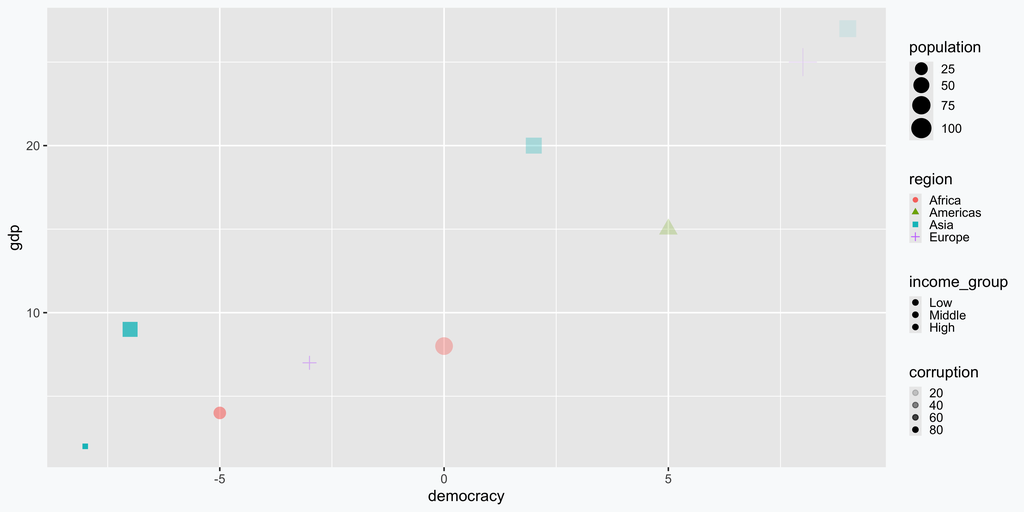

```r
# Overloaded example (hard to read): too many mapped aesthetics at once
# Prefer ≤2 mappings; prioritize the question your plot answers
ggplot(eg1, aes(x = democracy, y = gdp)) +
  geom_point(
    aes(color = region,
        fill  = income_group,
        shape = region,
        size  = population,
        alpha = corruption)
  )
```

## Mapping vs. Setting

### Key Idea

- **Mapping**: aesthetic varies with data → put inside `aes()`
- **Setting**: aesthetic is fixed → put outside `aes()`

This is how we create the data:

```r
eg2 <- data.frame(
  x = 1:5,
  y = c(2,4,6,8,10),
  group = c("A","B","A","B","A")
)
```

## Mapping vs. Setting

### Key Idea

- **Mapping**: aesthetic varies with data → put inside `aes()`
- **Setting**: aesthetic is fixed → put outside `aes()`

This is what it looks like:

| x | y | group |
| --- | --- | --- |
| 1 | 2 | A |
| 2 | 4 | B |
| 3 | 6 | A |
| 4 | 8 | B |
| 5 | 10 | A |

## Mapping vs. Setting

### Key Idea

- **Mapping**: aesthetic varies with data → put inside `aes()`
- **Setting**: aesthetic is fixed → put outside `aes()`

This is the difference:

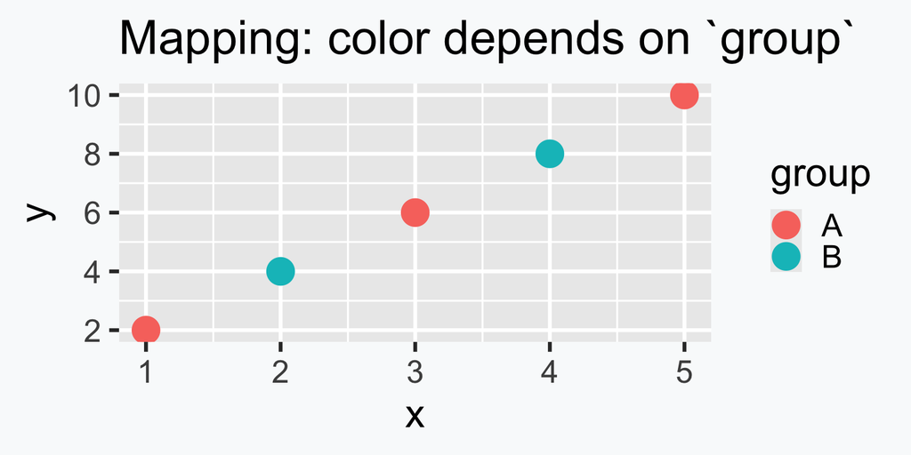

```r
# Mapping: put inside aes() when the value comes from data
# Setting: put outside aes() for a constant value
ggplot(eg2, aes(x = x, y = y, color = group)) +
  geom_point()+
  labs(title = "Mapping: color depends on `group`")
```

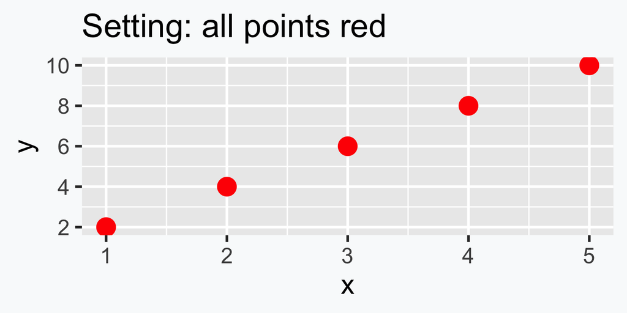

```r
# Mapping: put inside aes() when the value comes from data
# Setting: put outside aes() for a constant value
ggplot(eg2, aes(x = x, y = y)) +
  geom_point(color = "red") +
  labs(title = "Setting: all points red")
```

## Mapping vs. Setting

### Common Mistake

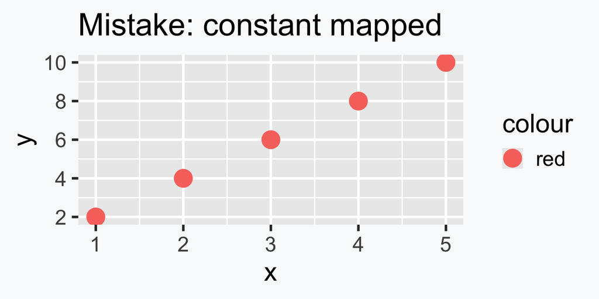

```r
# Wrong: constant inside aes()
ggplot(eg2, aes(x = x, y = y, color = "red")) +
  geom_point() +
  labs(title = "Mistake: constant mapped")
```

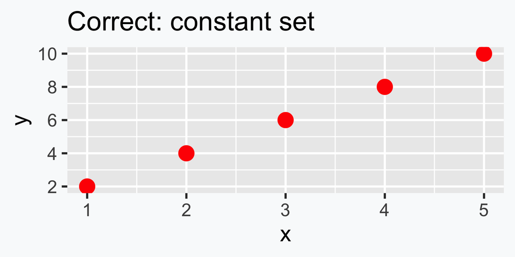

```r
# Correct: constant outside aes()
ggplot(eg2, aes(x = x, y = y)) +
  geom_point(color = "red") +
  labs(title = "Correct: constant set")
```

Why it’s wrong:

- Left plot: `"red"` treated as a category, so ggplot makes a useless legend.
- Right plot: `"red"` is just a style — no legend clutter.

# Column Aesthetics

## geom_col

### Aesthetics

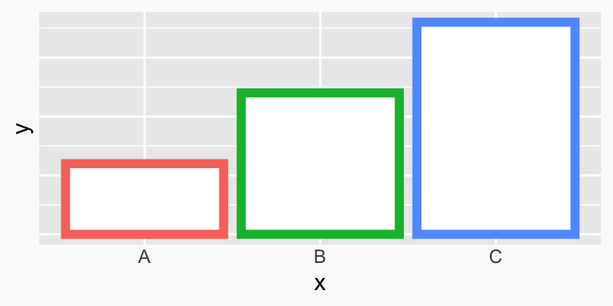

`color`(discrete)

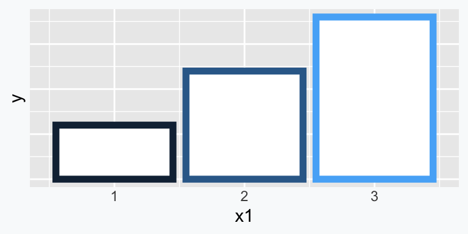

`color`(continuous)

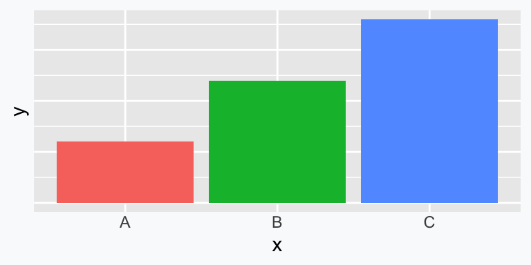

`fill`(discrete)

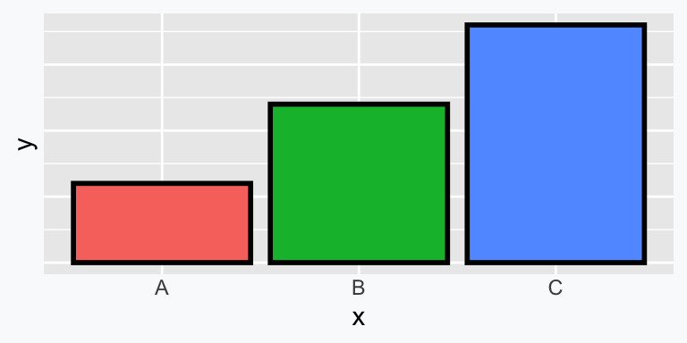

`fill` + `color` (black outline)

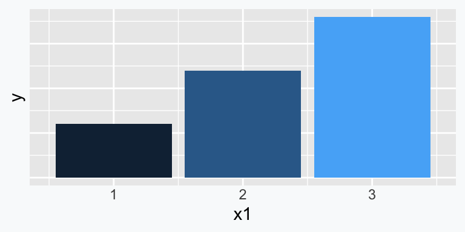

`fill`(continuous)

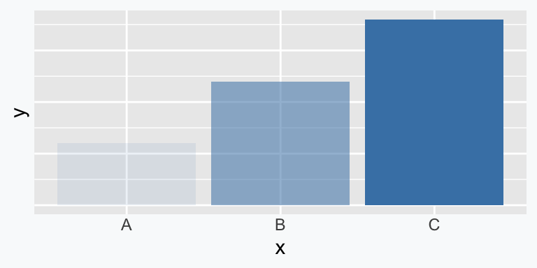

`alpha`(discrete + continuous)

## geom_col

### Aesthetics

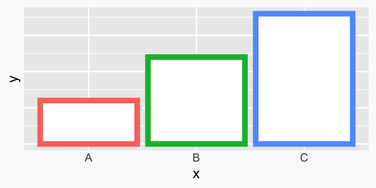

`color`(discrete)

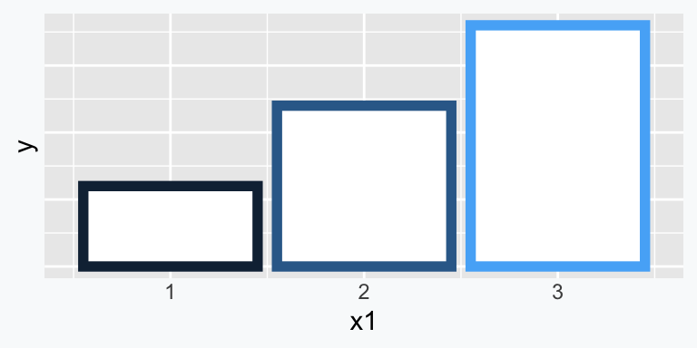

`color`(continuous)

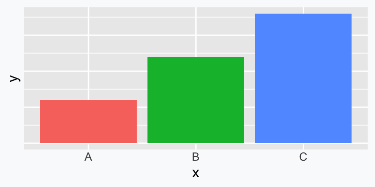

`fill`(discrete)

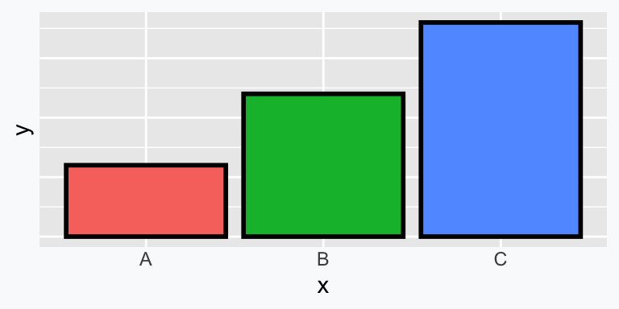

`fill` + `color` (black outline)

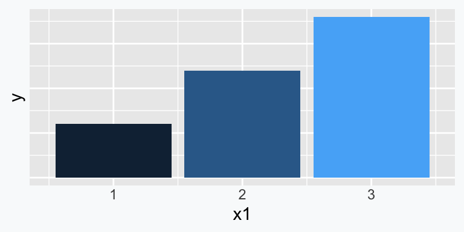

`fill`(continuous)

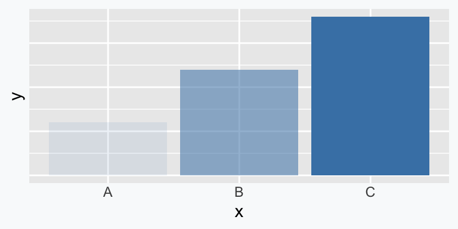

`alpha`(discrete + continuous)

| Aesthetic | Use for |
| --- | --- |
| `color` (discrete) | Differentiate categories with distinct outline hues (rare for bars) |
| `color` (continuous) | Show gradual change or intensity in outline scale (rare for bars) |
| `fill` (discrete) | Fill bars by category with distinct hues (common) |
| `fill` + `color` (outline) | Combine interior fill with a contrasting border for clarity |
| `fill` (continuous) | Show gradual change or intensity across a numeric fill scale (rare for bars) |
| `alpha` (discrete + continuous) | Control transparency to show emphasis or reduce clutter (rare for bars) |